# EDA on National Parks Data

Aubrey Smiley

11/1/2020

```r
npsdat <- read.csv("~/GitHub/national_parks/Data Files/NPS_with_Poverty_1995-2018.csv")
```

## Calculating Proportions of Public and Private Acres

```r
npsdat$publicAcres = npsdat$NPS.Fee.Acres/npsdat$Gross.Area.Acres
npsdat$privateAcres = npsdat$Private.Acres/npsdat$Gross.Area.Acres
```

## Selecting Park Fee From Entrance Fees column

```r
head(npsdat$entranceFees)
```

```
## [1] Denali Entrance Feeâ\200”Per Person (15.0000)
## [2] Free Entrance (0.0000)
## [3] No Entrance Fee (0.0000)
## [4] Free Entrance (0.0000)
## [5] Lake Clark Entrance and User Fees (0.0000)
## [6] Free Entrance (0.0000)
## 215 Levels: 1-Day Pass - Automobile (25.0000), 1-Day Pass - Motorcycle (25.0000), 1-Day Pass - Per Person (15.0000) ...
```

```r
npsdat$fees = sub("\\).*", "", sub(".*\\(", "", npsdat$entranceFees))
npsdat$fees<-gsub("\\..*","",npsdat$fees)
```

```r
npsdat$fees = strtoi(npsdat$fees)
head(npsdat$fees)
```

```
## [1] 15  0  0  0  0  0
```

```r
table(npsdat$fees)
```

```
##
##     0     1     2     3     4     5     7     8     9    10    12    15    20
## 56217   552  1104   552   276   708   552   871   276  3036   828  7644  2760
##    25    30    35    40    45    60   100   150   200   300
##  1932   828   276   828   276   276  1380   828   276   276
```

## Separating out Predictors

```r
X = subset(npsdat, select = -c(UnitCode, latitude, longitude, DateCreated, NPS.Fee.Acres, Private.Acres, Date, Month, RecreationVisits, activities, topics, entranceFees, RecreationHours))
colnames(X)
```

```
##  [1] "States"
##  [2] "Year"
##  [3] "ParkName"
##  [4] "ParkType"
##  [5] "NPFlag"
##  [6] "Region"
##  [7] "Age"
##  [8] "Gross.Area.Acres"
##  [9] "MonthName"
## [10] "Poverty.Percent..All.Ages"
## [11] "Poverty.Percent..Age.0.17"
## [12] "Poverty.Percent..Age.5.17.in.Families"
## [13] "Median.Household.Income"
## [14] "Poverty.Percent..Age.0.4"
## [15] "publicAcres"
## [16] "privateAcres"
## [17] "fees"
```

## Assigning our Supervisor

```r
Y = npsdat$RecreationVisits
```

## How much data is missing?

```r
sapply(X, function(x) sum(is.na(x)))
```

```
##                                States                                  Year
##                                     0                                     0
##                              ParkName                              ParkType
##                                     0                                     0
##                                NPFlag                                Region
##                                     0                                     0
##                                   Age                      Gross.Area.Acres
##                                   312                                   564
##                             MonthName             Poverty.Percent..All.Ages
##                                     0                                     0
##             Poverty.Percent..Age.0.17 Poverty.Percent..Age.5.17.in.Families
##                                     0                                     0
##               Median.Household.Income              Poverty.Percent..Age.0.4
##                                     0                                     0
##                           publicAcres                          privateAcres
##                                   564                                   564
##                                  fees
##                                  2508
```

```r
sum(is.na(Y))
```

```
## [1] 0
```

## Examining Age’s missing values

```r
missingAge = X[is.na(X$Age),]
```

## Only Oklahoma City National Memorial and Klondike Gold Rush Seattle Unit have missing values for age. Their acreage data is also missing.

### Oklahoma City National Memorial was founded in 1997 and is 3.3 acres. 3.12 acres are federal acres.

### Klondike Gold Rush - Seattle Unit was founded in 1976 and exists inside the Cadillac Hotel. We will substitute in 0.25 acres and it’s federally funded.

```r
X$Age[which(X$ParkName == "Oklahoma City")] <- X$Year[which(X$ParkName == "Oklahoma City")] - 1997
X$Age[which(X$ParkName == "Klondike Gold Rush - Seattle Unit")] <- X$Year[which(X$ParkName == "Klondike Gold Rush - Seattle Unit")] - 1976
X$Gross.Area.Acres[which(X$ParkName == "Oklahoma City")] <- 3.3
X$Gross.Area.Acres[which(X$ParkName == "Klondike Gold Rush - Seattle Unit")] <- 0.25
X$publicAcres[which(X$ParkName == "Oklahoma City")] <- 3.12/3.3
X$privateAcres[which(X$ParkName == "Oklahoma City")] <- (3.3-3.12)/3.3
X$publicAcres[which(X$ParkName == "Klondike Gold Rush - Seattle Unit")] <- 1
X$privateAcres[which(X$ParkName == "Klondike Gold Rush - Seattle Unit")] <- 0
```

## Now, let’s take a look at missing fees.

```r
missingfee = X[is.na(X$fees),]
length(unique(missingfee$ParkName))
```

```
## [1] 10
```

```r
length(unique(X$ParkName))
```

```
## [1] 328
```

## 10 out of 328 Parks are missing fees. This should be Google-able.

```r
X$fees[which(X$ParkName == "Casa Grande Ruins")] <- 10
X$fees[which(X$ParkName == "Devils Postpile")] <- 10
X$fees[which(X$ParkName == "City Of Rocks")] <- 0
X$fees[which(X$ParkName == "Lincoln Boyhood")] <- 0
X$fees[which(X$ParkName == "Scotts Bluff")] <- 0
X$fees[which(X$ParkName == "Carlsbad Caverns")] <- 15
X$fees[which(X$ParkName == "Pecos")] <- 0
X$fees[which(X$ParkName == "Stonewall")] <- 0
X$fees[which(X$ParkName == "Eisenhower")] <- 0
X$fees[which(X$ParkName == "Jewel Cave")] <- 8 # This is the average cost across several types of tours and tickets
X$fees[which(X$fees>0)] = 1
```

## Lastly, let’s examine the missing acreage

```r
missingacres = X[is.na(X$Gross.Area.Acres),]
```

## According to NPS History, found at http://www.npshistory.com/publications/foundation-documents/ania-fs-2009.pdf, Aniakchak’s full acreage was reliquished by the federal government to Native groups in the Native Claims Settlement Act of 1971.

```r
X$Gross.Area.Acres[which(X$ParkName == "Aniakchak")] = 601294
X$publicAcres[which(X$ParkName == "Aniakchak")] = 0
X$privateAcres[which(X$ParkName == "Aniakchak")] = 1
```

# Examining Distributions

```r
X %>%
  count(ParkType)
```

```
##                                 ParkType     n
## 1                                         3261
## 2         Ecological & Historic Preserve   276
## 3            International Historic Site    72
## 4                               Memorial   552
## 5               National and State Parks   276
## 6                   National Battlefield  2484
## 7              National Battlefield Park   924
## 8                 National Historic Site 16931
## 9               National Historical Park 10839
## 10 National Historical Park and Preserve   276
## 11                    National Lakeshore   828
## 12                     National Memorial  4152
## 13                National Military Park  1656
## 14                     National Monument 15702
## 15          National Monument & Preserve   804
## 16 National Monument and Historic Shrine   276
## 17          National Monument of America   276
## 18                         National Park 12971
## 19              National Park & Preserve  1920
## 20                     National Preserve  2028
## 21              National Recreation Area  2760
## 22                      National Reserve   276
## 23                        National River   552
## 24    National River and Recreation Area    96
## 25                 National Scenic River   456
## 26             National Scenic Riverways   276
## 27                     National Seashore  2208
## 28                                  Park  1656
## 29                   Wild & Scenic River   276
```

```r
X %>%
  count(NPFlag)
```

```
##   NPFlag     n
## 1      0 70169
## 2      1 14891
```

```r
X %>%
  count(Region)
```

```
##              Region     n
## 1            Alaska  4068
## 2    Intermountain  19886
## 3          Midwest  12650
## 4 National Capital   6633
## 5        Northeast  18157
## 6     Pacific West  11744
## 7        Southeast  11922
```

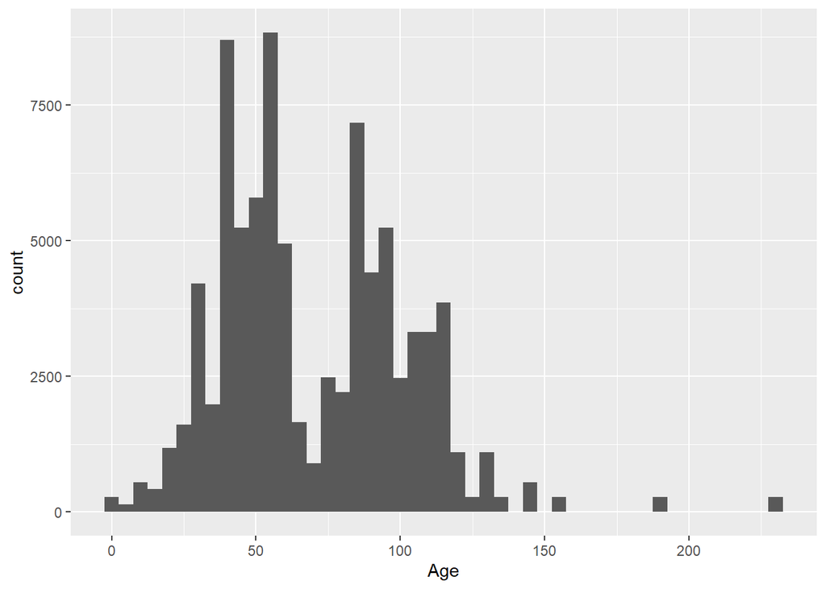

```r
ggplot(data = X) +
  geom_histogram(mapping = aes(x = Age), binwidth = 5)
```

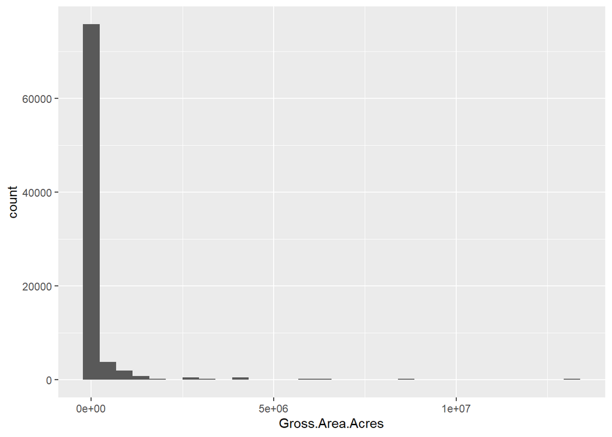

```r
ggplot(data = X) +
  geom_histogram(mapping = aes(x = Gross.Area.Acres))
```

### Gross Acreage will likely need a transformation.

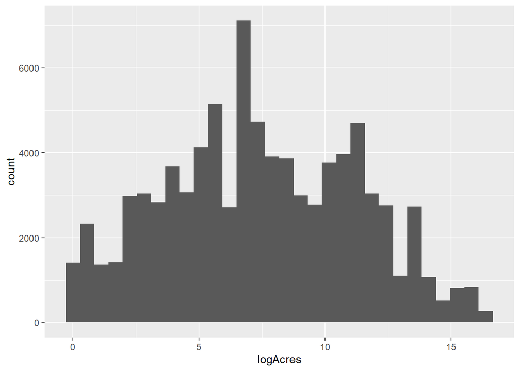

```r
X$logAcres = log(X$Gross.Area.Acres+1)
ggplot(data = X) +
  geom_histogram(mapping = aes(x = logAcres), )
```

```r
X = subset(X, select = -c(Gross.Area.Acres))
```

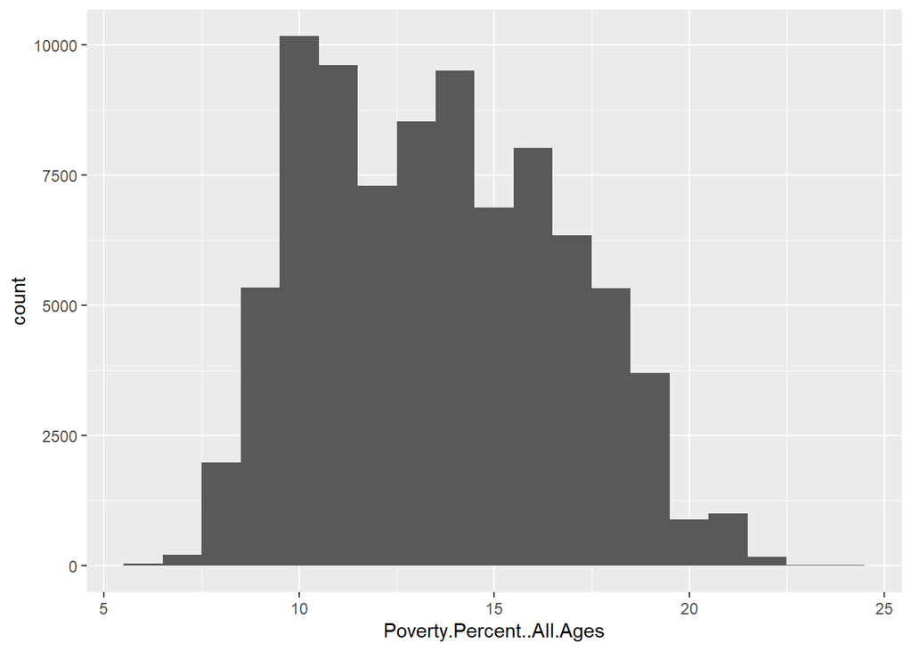

```r
ggplot(data = X) +
  geom_histogram(mapping = aes(x = Poverty.Percent..All.Ages), binwidth = 1)
```

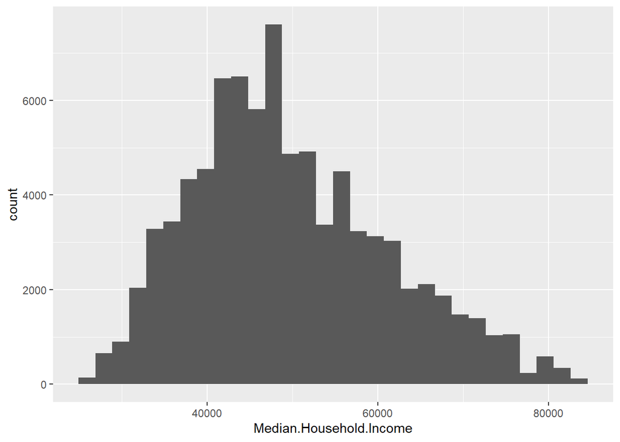

```r
ggplot(data = X) +
  geom_histogram(mapping = aes(x = Median.Household.Income))
```

## What about Y?

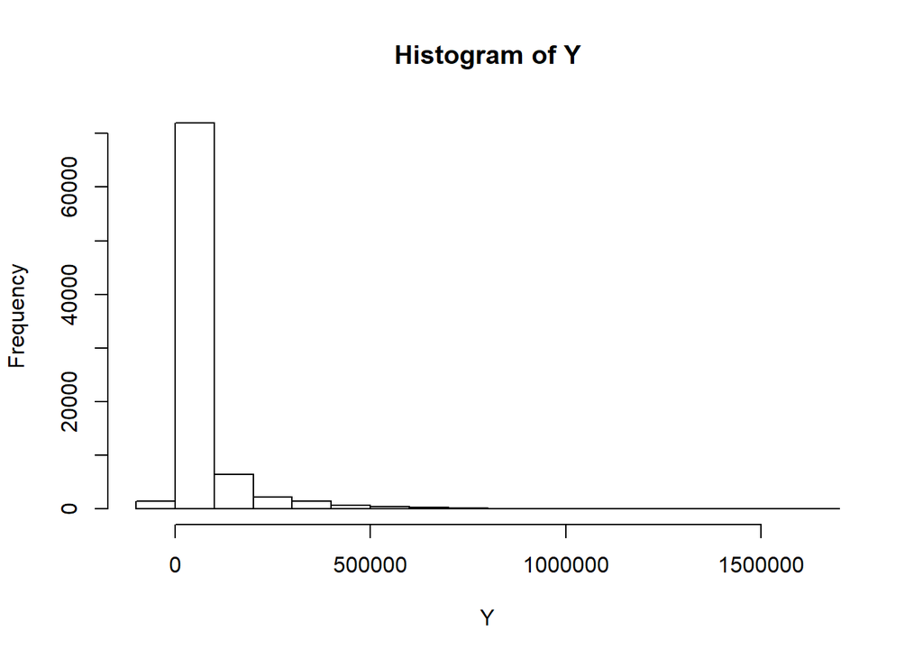

```r
hist(Y)
```

```r
Y[which(Y<0)] = 0
Y = log(Y+1)
```

## This looks much better.

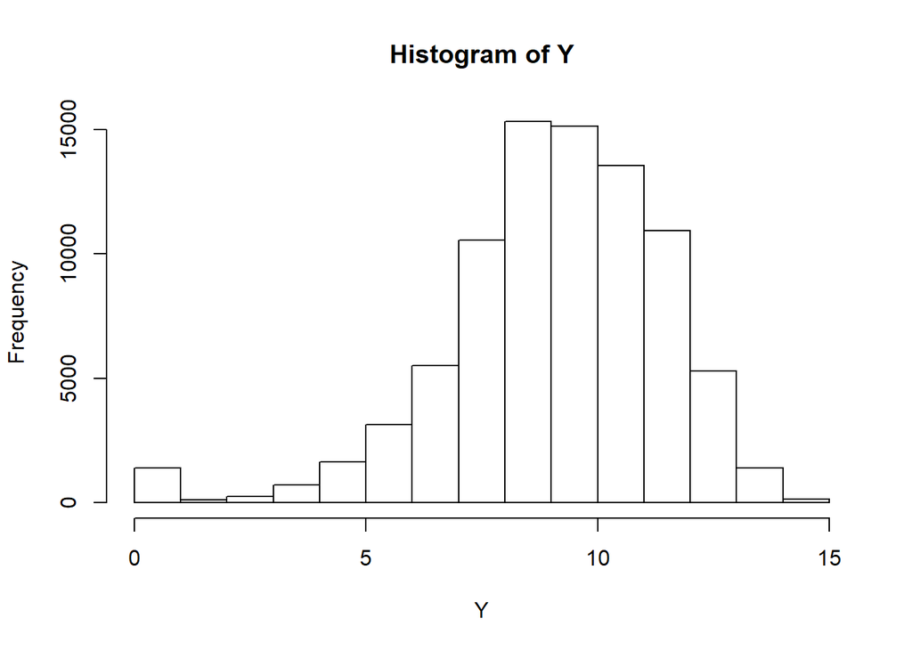

```r
hist(Y)
```

# How do our features relate to each other?

## First, we look at quantitative features.

## Visualization of correlations

```r
quantmat = subset(X, select = -c(States, ParkName, ParkType, NPFlag, Region, MonthName))
quantmat$Month = npsdat$Month
quantmat$Visits = npsdat$RecreationVisits
head(quantmat)
```

```
##   Year Age Poverty.Percent..All.Ages Poverty.Percent..Age.0.17
## 1 1995 104                      10.1                      14.8
## 2 1995  42                      10.1                      14.8
## 3 1995  42                      10.1                      14.8
## 4 1995  42                      10.1                      14.8
## 5 1995  42                      10.1                      14.8
## 6 1995  42                      10.1                      14.8
##   Poverty.Percent..Age.5.17.in.Families Median.Household.Income
## 1                                  11.2                   42255
## 2                                  11.2                   42255
## 3                                  11.2                   42255
## 4                                  11.2                   42255
## 5                                  11.2                   42255
## 6                                  11.2                   42255
##   Poverty.Percent..Age.0.4 publicAcres privateAcres fees logAcres Month Visits
## 1                     15.7   0.9937221  0.005240054    1 15.61970     1     84
## 2                     15.7   0.9942537  0.005564590    0 15.70062     9   1164
## 3                     15.7   0.9006642  0.070511740    0 13.41451    11     31
## 4                     15.7   0.9510997  0.032898824    0 13.38334     7    550
## 5                     15.7   0.9259044  0.048065885    0 15.20930     1    100
## 6                     15.7   0.9510997  0.032898824    0 13.38334    12     65
```

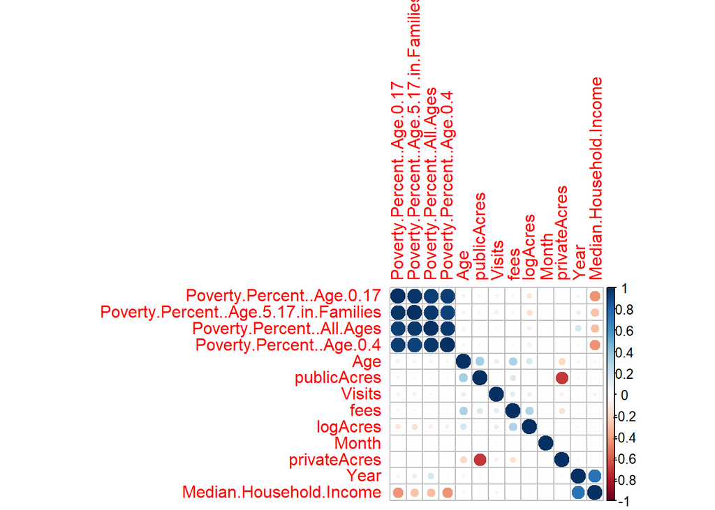

```r
quantcor = cor(quantmat)
corrplot(quantcor, order = "hclust")
```

```r
cor(Y, X$Poverty.Percent..Age.0.17)
```

```
## [1] 0.1315713
```

```r
cor(Y, X$Poverty.Percent..Age.5.17.in.Families)
```

```
## [1] 0.1369153
```

```r
cor(Y, X$Poverty.Percent..Age.0.4)
```

```
## [1] 0.1004023
```

```r
cor(Y, X$Poverty.Percent..All.Ages)
```

```
## [1] 0.1161952
```

## We are going to keep Poverty Percentage for ages 5-17 in families, because it has the strongest relationship with visitation

```r
quantmat2 = subset(quantmat, select = c(Poverty.Percent..Age.5.17.in.Families, Age, publicAcres, Visits, fees, logAcres, Month, privateAcres, Year, Median.Household.Income))
quantcor = cor(quantmat2, method = "spearman")
round(quantcor, 2)
```

```
##                                       Poverty.Percent..Age.5.17.in.Families
## Poverty.Percent..Age.5.17.in.Families                                  1.00
## Age                                                                    0.01
## publicAcres                                                            0.09
## Visits                                                                 0.12
## fees                                                                  -0.04
## logAcres                                                              -0.13
## Month                                                                  0.00
## privateAcres                                                          -0.05
## Year                                                                   0.12
## Median.Household.Income                                               -0.30
##                                         Age publicAcres Visits  fees logAcres
## Poverty.Percent..Age.5.17.in.Families  0.01        0.09   0.12 -0.04    -0.13
## Age                                    1.00        0.30   0.30  0.35     0.20
## publicAcres                            0.30        1.00  -0.07  0.12    -0.24
## Visits                                 0.30       -0.07   1.00  0.26     0.23
## fees                                   0.35        0.12   0.26  1.00     0.32
## logAcres                               0.20       -0.24   0.23  0.32     1.00
## Month                                  0.00        0.00   0.05  0.00     0.00
## privateAcres                          -0.21       -0.77   0.01 -0.13     0.28
## Year                                  -0.06       -0.01  -0.01 -0.02    -0.03
## Median.Household.Income               -0.06        0.03  -0.01  0.01    -0.03
##                                       Month privateAcres  Year
## Poverty.Percent..Age.5.17.in.Families  0.00        -0.05  0.12
## Age                                    0.00        -0.21 -0.06
## publicAcres                            0.00        -0.77 -0.01
## Visits                                 0.05         0.01 -0.01
## fees                                   0.00        -0.13 -0.02
## logAcres                               0.00         0.28 -0.03
## Month                                  1.00         0.00  0.00
## privateAcres                           0.00         1.00  0.01
## Year                                   0.00         0.01  1.00
## Median.Household.Income                0.00        -0.05  0.75
##                                       Median.Household.Income
## Poverty.Percent..Age.5.17.in.Families                   -0.30
## Age                                                     -0.06
## publicAcres                                              0.03
## Visits                                                  -0.01
## fees                                                     0.01
## logAcres                                                -0.03
## Month                                                    0.00
## privateAcres                                            -0.05
## Year                                                     0.75
## Median.Household.Income                                  1.00
```

## Based on these results, we’re going to drop private acres because public acres has a stronger relationship with visits.

```r
Xquant = subset(X, select = -c(States, ParkName, Poverty.Percent..Age.0.17, Poverty.Percent..Age.0.4, Poverty.Percent..All.Ages, privateAcres, MonthName))
Xquantclust = subset(X, select = -c(States, ParkName, Poverty.Percent..Age.0.17, Poverty.Percent..Age.0.4, Poverty.Percent..All.Ages, privateAcres, MonthName))
```

## Let’s look at some K-Means Solutions after Dimensionality Reduction

```r
Xquant$Visits = Y
Xquant$Month = npsdat$Month
Xquant$Region= as.numeric(factor(X$Region))
Xquant$ParkType= as.numeric(factor(X$ParkType))
sapply(Xquant, typeof)
```

```
##                                  Year                              ParkType
##                             "integer"                              "double"
##                                NPFlag                                Region
##                             "integer"                              "double"
##                                   Age Poverty.Percent..Age.5.17.in.Families
##                              "double"                              "double"
##               Median.Household.Income                           publicAcres
##                             "integer"                              "double"
##                                  fees                              logAcres
##                              "double"                              "double"
##                                Visits                                 Month
##                              "double"                             "integer"
```

```r
Xquant = sapply(Xquant, as.numeric)
```

```r
Xquantclust = subset(X, select = -c(States, ParkName, Poverty.Percent..Age.0.17, Poverty.Percent..Age.0.4, Poverty.Percent..All.Ages, privateAcres, MonthName))
```

## Let’s look at some K-Means Solutions after Dimensionality Reduction

```r
Xquantclust$Visits = Y
Xquantclust$Month = npsdat$Month
Xquantclust$Region= factor(X$Region)
Xquantclust$ParkType= factor(X$ParkType)
```

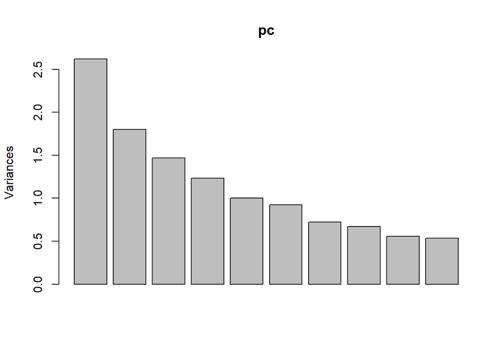

```r
pc = prcomp(Xquant, center = TRUE, scale = TRUE)
plot(pc)
```

```r
summary(pc)
```

```
## Importance of components:
##                           PC1    PC2    PC3    PC4     PC5    PC6     PC7
## Standard deviation     1.6188 1.3422 1.2122 1.1100 1.00076 0.9600 0.85107
## Proportion of Variance 0.2184 0.1501 0.1225 0.1027 0.08346 0.0768 0.06036
## Cumulative Proportion  0.2184 0.3685 0.4909 0.5936 0.67708 0.7539 0.81424
##                            PC8     PC9    PC10    PC11    PC12
## Standard deviation     0.81761 0.74578 0.73164 0.55106 0.40677
## Proportion of Variance 0.05571 0.04635 0.04461 0.02531 0.01379
## Cumulative Proportion  0.86995 0.91630 0.96091 0.98621 1.00000
```

```r
comp = matrix(pc$x[,1:9])
```

```r
require(knor)
nthread <- 4
K = 3
kmeans.out <- Kmeans(comp, K, iter.max = 100, nthread=nthread)
names(kmeans.out)
```

```
## [1] "nrow"    "ncol"    "iters"   "k"       "centers" "cluster" "size"
```

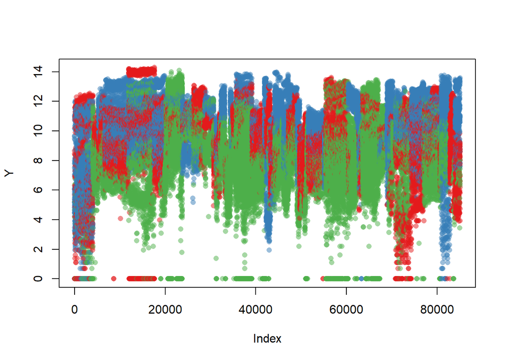

```r
palette(alpha(brewer.pal(9,'Set1'), 0.5))
plot(Y, col=kmeans.out$cluster, pch=16)
```

#What if we don’t use PCA?

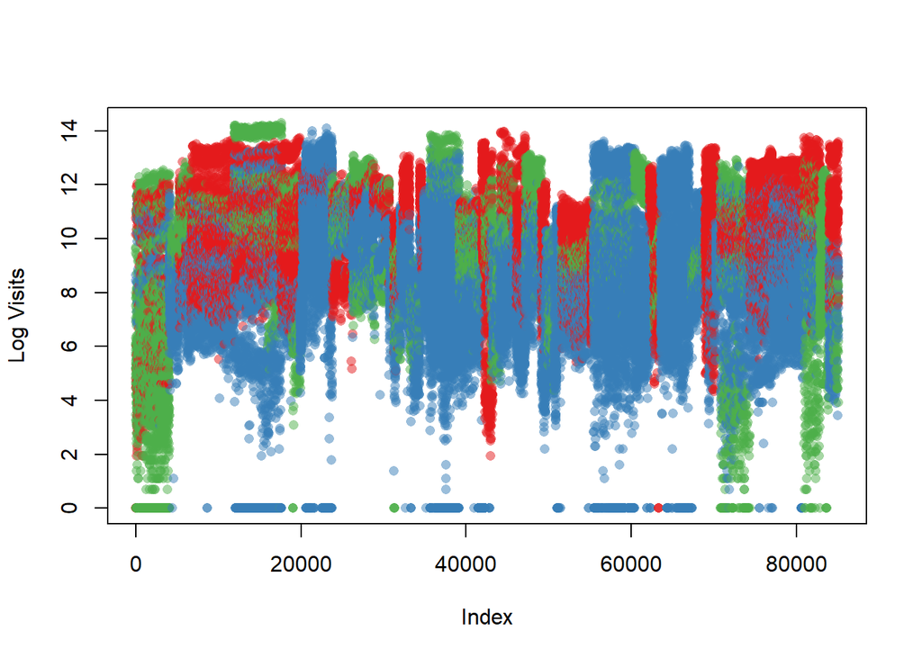

```r
require(knor)
nthread <- 4
K = 3
kmeans2.out <- Kmeans(scale(Xquant), K, iter.max = 100, nthread=nthread)
plot(Y, col=kmeans2.out$cluster, pch=16, ylab = "Log Visits")
```

```r
frame = data.frame(exp(Y), Xquantclust, kmeans2.out$cluster)
names(frame)[names(frame) == "exp.Y."] <- "Visitors"
names(frame)[names(frame) == "kmeans2.out.cluster"] <- "Cluster"
names(frame)[names(frame) == "Poverty.Percent..Age.5.17.in.Families"] <- "Poverty"
frame = select(frame, -c(Year))
head(frame)
```

```
##   Visitors                 ParkType NPFlag Region Age Poverty
## 1       85 National Park & Preserve      1 Alaska 104    11.2
## 2     1165        National Preserve      0 Alaska  42    11.2
## 3       32            National Park      1 Alaska  42    11.2
## 4      551        National Monument      0 Alaska  42    11.2
## 5      101 National Park & Preserve      1 Alaska  42    11.2
## 6       66        National Monument      0 Alaska  42    11.2
##   Median.Household.Income publicAcres fees logAcres   Visits Month Cluster
## 1                   42255   0.9937221    1 15.61970 4.442651     1       1
## 2                   42255   0.9942537    0 15.70062 7.060476     9       3
## 3                   42255   0.9006642    0 13.41451 3.465736    11       3
## 4                   42255   0.9510997    0 13.38334 6.311735     7       3
## 5                   42255   0.9259044    0 15.20930 4.615121     1       3
## 6                   42255   0.9510997    0 13.38334 4.189655    12       3
```

```r
cluster1 = frame[frame$Cluster == 1,]
cluster2 = frame[frame$Cluster == 2,]
cluster3 = frame[frame$Cluster == 3,]
#print("Cluster 1 Summary: \n")
#summary(cluster1)
#print("\nCluster 2 Summary: \n")
#summary(cluster2)
#print("\nCluster3 Summary: \n")
#summary(cluster3)
```

```r
# make dataset with a few variables to summarize
shortclust1 <- cluster1 %>% select(Visitors, Region, Poverty, Median.Household.Income, publicAcres, fees)
shortclust2 <- cluster2 %>% select(Visitors, Region, Poverty, Median.Household.Income, publicAcres, fees)
shortclust3 <- cluster3 %>% select(Visitors, Region, Poverty, Median.Household.Income, publicAcres, fees)
# summarize the data with our package
table1 <- tbl_summary(shortclust1)
table2 <- tbl_summary(shortclust2)
table3 <- tbl_summary(shortclust3)
table1
```

| **Characteristic** | **N = 21,250**<sup>1</sup> |
| --- | --- |
| Visitors | 32,819 (9,033, 95,072) |
| Region |  |
| Alaska | 751 (3.5%) |
| Intermountain | 9,912 (47%) |
| Midwest | 3,036 (14%) |
| National Capital | 541 (2.5%) |
| Northeast | 1,379 (6.5%) |
| Pacific West | 4,513 (21%) |
| Southeast | 1,118 (5.3%) |
| Poverty | 17.1 (13.1, 21.4) |
| Median.Household.Income | 47,224 (40,686, 55,735) |
| publicAcres | 1.00 (0.96, 1.00) |
| fees | 19,398 (91%) |

<sup>*1*</sup> Statistics presented: Median (IQR); n (%)

```r
table2
```

| **Characteristic** | **N = 48,173**<sup>1</sup> |
| --- | --- |
| Visitors | 5,990 (1,836, 21,973) |
| Region |  |
| Alaska | 276 (0.6%) |
| Intermountain | 7,480 (16%) |
| Midwest | 7,370 (15%) |
| National Capital | 4,977 (10%) |
| Northeast | 15,396 (32%) |
| Pacific West | 4,262 (8.8%) |
| Southeast | 8,412 (17%) |
| Poverty | 17.8 (13.5, 21.9) |
| Median.Household.Income | 47,796 (41,419, 56,811) |
| publicAcres | 0.98 (0.81, 1.00) |
| fees | 5,991 (12%) |

<sup>*1*</sup> Statistics presented: Median (IQR); n (%)

```r
table3
```

| **Characteristic** | **N = 15,637**<sup>1</sup> |
| --- | --- |
| Visitors | 15,622 (1,748, 64,158) |
| Region |  |
| Alaska | 3,041 (19%) |
| Intermountain | 2,494 (16%) |
| Midwest | 2,244 (14%) |
| National Capital | 1,115 (7.1%) |
| Northeast | 1,382 (8.8%) |
| Pacific West | 2,969 (19%) |
| Southeast | 2,392 (15%) |
| Poverty | 16.4 (12.8, 21.2) |
| Median.Household.Income | 49,133 (42,169, 59,928) |
| publicAcres | 0.69 (0.31, 0.95) |
| fees | 2,050 (13%) |

<sup>*1*</sup> Statistics presented: Median (IQR); n (%)